# Telecom Customer Churn Prediction

TO 628 Group 8

4/14/2020

## Introduction

The objective of this project is to predict churn or no churn in order to retain the customers in the telco company. The reason we choose this topic is that customer churn is one of the most important metrics for a business to evaluate. Customer churn impedes growth, so companies should have a sense of which kind of group are going to stop to use its product / service.

### About the data (from data description on Kaggle)

https://www.kaggle.com/blastchar/telco-customer-churn

The data set includes information about:

- Customers who left within the last month – the column is called Churn
- Services that each customer has signed up for – phone, multiple lines, internet, online security, online backup, device protection, tech support, and streaming TV and movies
- Customer account information – how long they’ve been a customer, contract, payment method, paperless billing, monthly charges, and total charges
- Demographic info about customers – gender, age range, and if they have partners and dependents

```r
library(dplyr)
```

```r
library(corrplot)
library(randomForest)
library(caret)
library(kernlab)
library(neuralnet)
library(gmodels)
library(C50)
```

### Data Exploration

```r
data <- read.csv("Churn.csv")
```

```r
str(data)
```

```
## 'data.frame':    7043 obs. of  21 variables:
##  $ customerID      : Factor w/ 7043 levels "0002-ORFBO","0003-MKNFE",..: 5376 3963 2565 5536 6512 6552 1003 4771 5605 4535 ...
##  $ gender          : Factor w/ 2 levels "Female","Male": 1 2 2 2 1 1 2 1 1 2 ...
##  $ SeniorCitizen   : int  0 0 0 0 0 0 0 0 0 0 ...
##  $ Partner         : Factor w/ 2 levels "No","Yes": 2 1 1 1 1 1 1 1 2 1 ...
##  $ Dependents      : Factor w/ 2 levels "No","Yes": 1 1 1 1 1 1 2 1 1 2 ...
##  $ tenure          : int  1 34 2 45 2 8 22 10 28 62 ...
##  $ PhoneService    : Factor w/ 2 levels "No","Yes": 1 2 2 1 2 2 2 1 2 2 ...
##  $ MultipleLines   : Factor w/ 3 levels "No","No phone service",..: 2 1 1 2 1 3 3 2 3 1 ...
##  $ InternetService : Factor w/ 3 levels "DSL","Fiber optic",..: 1 1 1 1 2 2 2 1 2 1 ...
##  $ OnlineSecurity  : Factor w/ 3 levels "No","No internet service",..: 1 3 3 3 1 1 1 3 1 3 ...
##  $ OnlineBackup    : Factor w/ 3 levels "No","No internet service",..: 3 1 3 1 1 1 3 1 1 3 ...
##  $ DeviceProtection: Factor w/ 3 levels "No","No internet service",..: 1 3 1 3 1 3 1 1 3 1 ...
##  $ TechSupport     : Factor w/ 3 levels "No","No internet service",..: 1 1 1 3 1 1 1 1 3 1 ...
##  $ StreamingTV     : Factor w/ 3 levels "No","No internet service",..: 1 1 1 1 1 3 3 1 3 1 ...
##  $ StreamingMovies : Factor w/ 3 levels "No","No internet service",..: 1 1 1 1 1 3 1 1 3 1 ...
##  $ Contract        : Factor w/ 3 levels "Month-to-month",..: 1 2 1 2 1 1 1 1 1 2 ...
##  $ PaperlessBilling: Factor w/ 2 levels "No","Yes": 2 1 2 1 2 2 2 1 2 1 ...
##  $ PaymentMethod   : Factor w/ 4 levels "Bank transfer (automatic)",..: 3 4 4 1 3 3 2 4 3 1 ...
##  $ MonthlyCharges  : num  29.9 57 53.9 42.3 70.7 ...
##  $ TotalCharges    : num  29.9 1889.5 108.2 1840.8 151.7 ...
##  $ Churn           : Factor w/ 2 levels "No","Yes": 1 1 2 1 2 2 1 1 2 1 ...
```

```r
summary(data)
```

```
##       customerID      gender     SeniorCitizen    Partner    Dependents
##  0002-ORFBO:   1   Female:3488   Min.   :0.0000   No :3641   No :4933
##  0003-MKNFE:   1   Male  :3555   1st Qu.:0.0000   Yes:3402   Yes:2110
##  0004-TLHLJ:   1                 Median :0.0000
##  0011-IGKFF:   1                 Mean   :0.1621
##  0013-EXCHZ:   1                 3rd Qu.:0.0000
##  0013-MHZWF:   1                 Max.   :1.0000
##  (Other)   :7037
##      tenure      PhoneService          MultipleLines     InternetService
##  Min.   : 0.00   No : 682     No              :3390   DSL        :2421
##  1st Qu.: 9.00   Yes:6361     No phone service: 682   Fiber optic:3096
##  Median :29.00                Yes             :2971   No         :1526
##  Mean   :32.37
##  3rd Qu.:55.00
##  Max.   :72.00
##
##              OnlineSecurity              OnlineBackup
##  No                 :3498   No                 :3088
##  No internet service:1526   No internet service:1526
##  Yes                :2019   Yes                :2429
##
##
##
##
##             DeviceProtection              TechSupport
##  No                 :3095    No                 :3473
##  No internet service:1526    No internet service:1526
##  Yes                :2422    Yes                :2044
##
##
##
##
##               StreamingTV              StreamingMovies           Contract
##  No                 :2810   No                 :2785   Month-to-month:3875
##  No internet service:1526   No internet service:1526   One year      :1473
##  Yes                :2707   Yes                :2732   Two year      :1695
##
##
##
##
##  PaperlessBilling                   PaymentMethod  MonthlyCharges
##  No :2872         Bank transfer (automatic):1544   Min.   : 18.25
##  Yes:4171         Credit card (automatic)  :1522   1st Qu.: 35.50
##                   Electronic check         :2365   Median : 70.35
##                   Mailed check             :1612   Mean   : 64.76
##                                                    3rd Qu.: 89.85
##                                                    Max.   :118.75
##
##   TotalCharges    Churn
##  Min.   :  18.8   No :5174
##  1st Qu.: 401.4   Yes:1869
##  Median :1397.5
##  Mean   :2283.3
##  3rd Qu.:3794.7
##  Max.   :8684.8
##  NA's   :11
```

**Factor**

```r
# Factor seniorcitizen
data$SeniorCitizen <- as.factor(data$SeniorCitizen)
```

**Missing Values** There are only 11 missing values in TotalCharges column, the number of missing values is relatively small, so we decide to remove those 11 rows.

```r
# remove the rows with missing value
data <- na.omit(data)
```

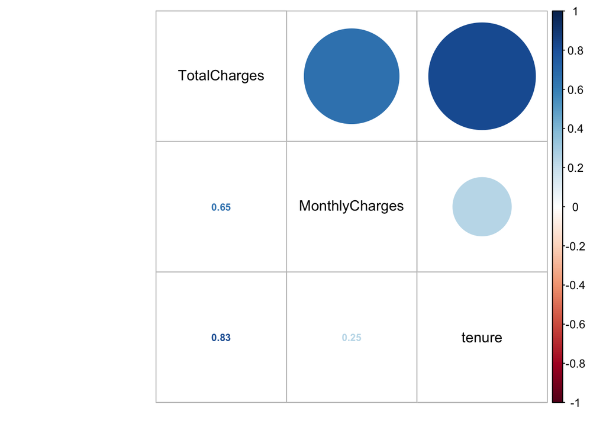

```r
data %>%
  dplyr::select (TotalCharges, MonthlyCharges, tenure) %>%
  cor() %>%
  corrplot.mixed(upper = "circle", tl.col = "black", number.cex = 0.7)
```

Correlation between tunure and TotalCharge, TotalCharges and MonthlyCharges

```r
#set bins of tenure
data$tenure[data$tenure >=0 & data$tenure <= 12] <- '0-1 year'
data$tenure[data$tenure >=12 & data$tenure <= 24] <- '1-2 year'
data$tenure[data$tenure >=24 & data$tenure <= 36] <- '2-3 year'
data$tenure[data$tenure >=36 & data$tenure <= 48] <- '3-4 year'
data$tenure[data$tenure >=48 & data$tenure <= 60] <- '4-5 year'
data$tenure[data$tenure >=60 & data$tenure <= 72] <- '5-6 year'

data$tenure <- as.factor(data$tenure)
```

```r
#Remove customerID
data$customerID <- NULL
```

```r
# replace the categorical feature "No phone service" and "No Internet Service Service" to "No"
data <- data.frame(lapply(data, function(x) {
                  gsub("No internet service", "No", x)}))

data <- data.frame(lapply(data, function(x) {
                  gsub("No phone service", "No", x)}))

num_columns <- c("MonthlyCharges", "TotalCharges")
data[num_columns] <- sapply(data[num_columns], as.numeric)
```

```r
normalize <- function(x) {
  return ((x - min(x)) / (max(x) - min(x)))
}
data[num_columns] <- sapply(data[num_columns], normalize)
```

```r
set.seed(111)

# Split data, 80% distribution of churn for training
train.index <- createDataPartition(
    y = data$Churn, p = 0.8, list = FALSE
)
train <- data[train.index,]
test <- data[-train.index,]
```

```r
#Simple logistic regression
logit.model <- glm(Churn ~ ., data = train, family = "binomial")
summary(logit.model)
```

```
##
## Call:
## glm(formula = Churn ~ ., family = "binomial", data = train)
##
## Deviance Residuals:
##     Min       1Q   Median       3Q      Max
## -1.9467  -0.6705  -0.2901   0.6902   3.1135
##
## Coefficients:
##                                       Estimate Std. Error z value Pr(>|z|)
## (Intercept)                          -0.043980   0.195627  -0.225 0.822124
## genderMale                           -0.008699   0.072495  -0.120 0.904484
## SeniorCitizen1                        0.228065   0.096206   2.371 0.017760 *
## PartnerYes                           -0.085100   0.087282  -0.975 0.329556
## DependentsYes                        -0.129763   0.101076  -1.284 0.199208
## tenure1-2 year                       -0.895371   0.114498  -7.820 5.28e-15 ***
## tenure2-3 year                       -1.186310   0.133531  -8.884  < 2e-16 ***
## tenure3-4 year                       -1.311538   0.149869  -8.751  < 2e-16 ***
## tenure4-5 year                       -1.490742   0.159205  -9.364  < 2e-16 ***
## tenure5-6 year                       -1.707058   0.193697  -8.813  < 2e-16 ***
## PhoneServiceYes                      -0.398871   0.144032  -2.769 0.005617 **
## MultipleLinesYes                      0.211143   0.088999   2.372 0.017672 *
## InternetServiceFiber optic            1.011072   0.106283   9.513  < 2e-16 ***
## InternetServiceNo                    -0.981202   0.163039  -6.018 1.76e-09 ***
## OnlineSecurityYes                    -0.361630   0.093611  -3.863 0.000112 ***
## OnlineBackupYes                      -0.124957   0.085129  -1.468 0.142142
## DeviceProtectionYes                  -0.048288   0.088259  -0.547 0.584301
## TechSupportYes                       -0.385749   0.096243  -4.008 6.12e-05 ***
## StreamingTVYes                        0.281714   0.089818   3.137 0.001710 **
## StreamingMoviesYes                    0.187767   0.089050   2.109 0.034984 *
## ContractOne year                     -0.784039   0.120273  -6.519 7.09e-11 ***
## ContractTwo year                     -1.623304   0.203620  -7.972 1.56e-15 ***
## PaperlessBillingYes                   0.275141   0.083129   3.310 0.000934 ***
## PaymentMethodCredit card (automatic) -0.027998   0.127187  -0.220 0.825771
## PaymentMethodElectronic check         0.328776   0.105767   3.108 0.001880 **
## PaymentMethodMailed check            -0.005070   0.128343  -0.040 0.968488
## MonthlyCharges                       -0.356792   0.146441  -2.436 0.014834 *
## TotalCharges                         -0.011003   0.146277  -0.075 0.940042
## ---
## Signif. codes:  0 '***' 0.001 '**' 0.01 '*' 0.05 '.' 0.1 ' ' 1
##
## (Dispersion parameter for binomial family taken to be 1)
##
##     Null deviance: 6517.2  on 5626  degrees of freedom
## Residual deviance: 4694.5  on 5599  degrees of freedom
## AIC: 4750.5
##
## Number of Fisher Scoring iterations: 6
```

```r
pred <- predict(logit.model, type = "response", newdata = test)
summary(pred)
```

```
##     Min.  1st Qu.   Median     Mean  3rd Qu.     Max.
## 0.005751 0.045410 0.191114 0.269544 0.462132 0.881933
```

```r
#test$prob <- pred

# Using probability cutoff of 50%.
logit.pred_churn <- factor(ifelse(pred >= 0.5, "Yes", "No"))
actual_churn <- factor(ifelse(test$Churn == "Yes","Yes","No"))



CrossTable(test$Churn, logit.pred_churn,
           prop.chisq = FALSE, prop.c = FALSE, prop.r = FALSE,
           dnn = c('actual default', 'predicted default'))
```

```
##
##
##    Cell Contents
## |-------------------------|
## |                       N |
## |         N / Table Total |
## |-------------------------|
##
##
## Total Observations in Table:  1405
##
##
##                | predicted default
## actual default |        No |       Yes | Row Total |
## ---------------|-----------|-----------|-----------|
##             No |       927 |       105 |      1032 |
##                |     0.660 |     0.075 |           |
## ---------------|-----------|-----------|-----------|
##            Yes |       175 |       198 |       373 |
##                |     0.125 |     0.141 |           |
## ---------------|-----------|-----------|-----------|
##   Column Total |      1102 |       303 |      1405 |
## ---------------|-----------|-----------|-----------|
##
##
```

[output not shown]

```r
#Improved logistic regression
logit.model2 <- glm(Churn ~ tenure + InternetService + SeniorCitizen + PhoneService + MultipleLines + OnlineSecurity + TechSupport + StreamingTV + Contract + PaperlessBilling + PaymentMethod + MonthlyCharges, data = train, family = binomial)

summary(logit.model2)
```

```
##
## Call:
## glm(formula = Churn ~ tenure + InternetService + SeniorCitizen +
##     PhoneService + MultipleLines + OnlineSecurity + TechSupport +
##     StreamingTV + Contract + PaperlessBilling + PaymentMethod +
##     MonthlyCharges, family = binomial, data = train)
##
## Deviance Residuals:
##     Min       1Q   Median       3Q      Max
## -1.9176  -0.6771  -0.2911   0.6860   3.0860
##
## Coefficients:
##                                      Estimate Std. Error z value Pr(>|z|)
## (Intercept)                          -0.10508    0.17234  -0.610 0.542041
## tenure1-2 year                       -0.91865    0.10684  -8.599  < 2e-16 ***
## tenure2-3 year                       -1.23008    0.12698  -9.687  < 2e-16 ***
## tenure3-4 year                       -1.36442    0.14525  -9.394  < 2e-16 ***
## tenure4-5 year                       -1.55730    0.15315 -10.168  < 2e-16 ***
## tenure5-6 year                       -1.79828    0.18362  -9.794  < 2e-16 ***
## InternetServiceFiber optic            1.03457    0.10513   9.841  < 2e-16 ***
## InternetServiceNo                    -0.97554    0.15817  -6.168 6.92e-10 ***
## SeniorCitizen1                        0.25151    0.09417   2.671 0.007563 **
## PhoneServiceYes                      -0.40738    0.14339  -2.841 0.004494 **
## MultipleLinesYes                      0.21531    0.08870   2.427 0.015205 *
## OnlineSecurityYes                    -0.37355    0.09328  -4.004 6.22e-05 ***
## TechSupportYes                       -0.38435    0.09578  -4.013 6.00e-05 ***
## StreamingTVYes                        0.32660    0.08496   3.844 0.000121 ***
## ContractOne year                     -0.78513    0.11899  -6.598 4.16e-11 ***
## ContractTwo year                     -1.63080    0.20238  -8.058 7.75e-16 ***
## PaperlessBillingYes                   0.28213    0.08284   3.406 0.000660 ***
## PaymentMethodCredit card (automatic) -0.02710    0.12698  -0.213 0.830996
## PaymentMethodElectronic check         0.34201    0.10553   3.241 0.001191 **
## PaymentMethodMailed check            -0.00390    0.12797  -0.030 0.975684
## MonthlyCharges                       -0.36208    0.14425  -2.510 0.012067 *
## ---
## Signif. codes:  0 '***' 0.001 '**' 0.01 '*' 0.05 '.' 0.1 ' ' 1
##
## (Dispersion parameter for binomial family taken to be 1)
##
##     Null deviance: 6517.2  on 5626  degrees of freedom
## Residual deviance: 4706.0  on 5606  degrees of freedom
## AIC: 4748
##
## Number of Fisher Scoring iterations: 6
```

```r
pred2 <- predict(logit.model2, type = "response", newdata = test)
summary(pred2)
```

```
##     Min.  1st Qu.   Median     Mean  3rd Qu.     Max.
## 0.006544 0.044448 0.202116 0.269438 0.457760 0.874064
```

```r
#test$prob <- pred

# Using probability cutoff of 50%.
logit.pred_churn2 <- factor(ifelse(pred2 >= 0.5, "Yes", "No"))
actual_churn2 <- factor(ifelse(test$Churn == "Yes","Yes","No"))

CrossTable(test$Churn, logit.pred_churn2,
           prop.chisq = FALSE, prop.c = FALSE, prop.r = FALSE,
           dnn = c('actual default', 'predicted default'))
```

```
##
##
##    Cell Contents
## |-------------------------|
## |                       N |
## |         N / Table Total |
## |-------------------------|
##
##
## Total Observations in Table:  1405
##
##
##                | predicted default
## actual default |        No |       Yes | Row Total |
## ---------------|-----------|-----------|-----------|
##             No |       932 |       100 |      1032 |
##                |     0.663 |     0.071 |           |
## ---------------|-----------|-----------|-----------|
##            Yes |       176 |       197 |       373 |
##                |     0.125 |     0.140 |           |
## ---------------|-----------|-----------|-----------|
##   Column Total |      1108 |       297 |      1405 |
## ---------------|-----------|-----------|-----------|
##
##
```

[output not shown]

```r
accuracy <- function(predicted, trueval, model, hideoutput = F) {
  stopifnot(length(predicted) == length(trueval))
  result <- sum(predicted == trueval) / length(predicted)
  if (!hideoutput) {cat("Model:", model, "had", result, "accuracy\n")}
  return(result)
}
```

```r
decisionTree <- C5.0(train[-20], train$Churn)
decisionTree_pred <- predict(decisionTree, test)
CrossTable(test$Churn, decisionTree_pred, prop.chisq = FALSE, prop.c = FALSE, prop.r = FALSE,dnn = c('actual default', 'predicted default'))
```

```
##
##
##    Cell Contents
## |-------------------------|
## |                       N |
## |         N / Table Total |
## |-------------------------|
##
##
## Total Observations in Table:  1405
##
##
##                | predicted default
## actual default |        No |       Yes | Row Total |
## ---------------|-----------|-----------|-----------|
##             No |       919 |       113 |      1032 |
##                |     0.654 |     0.080 |           |
## ---------------|-----------|-----------|-----------|
##            Yes |       175 |       198 |       373 |
##                |     0.125 |     0.141 |           |
## ---------------|-----------|-----------|-----------|
##   Column Total |      1094 |       311 |      1405 |
## ---------------|-----------|-----------|-----------|
##
##
```

```r
acc_dt = accuracy(decisionTree_pred, test$Churn, "Random Forest Classification", TRUE)
acc_dt
```

```
## [1] 0.7950178
```

[output not shown]

```r
#RandomForest Model
rf.model <- randomForest(Churn ~ ., data = train)
rfpred <- predict(rf.model, newdata = test)
#summary(rfpred)
CrossTable(test$Churn, rfpred, prop.chisq = FALSE, prop.c = FALSE, prop.r = FALSE,dnn = c('actual default', 'predicted default'))
```

```
##
##
##    Cell Contents
## |-------------------------|
## |                       N |
## |         N / Table Total |
## |-------------------------|
##
##
## Total Observations in Table:  1405
##
##
##                | predicted default
## actual default |        No |       Yes | Row Total |
## ---------------|-----------|-----------|-----------|
##             No |       919 |       113 |      1032 |
##                |     0.654 |     0.080 |           |
## ---------------|-----------|-----------|-----------|
##            Yes |       184 |       189 |       373 |
##                |     0.131 |     0.135 |           |
## ---------------|-----------|-----------|-----------|
##   Column Total |      1103 |       302 |      1405 |
## ---------------|-----------|-----------|-----------|
##
##
```

```r
acc_rf = accuracy(rfpred, test$Churn, TRUE)
```

```
## Model: TRUE had 0.7886121 accuracy
```

```r
acc_rf
```

```
## [1] 0.7886121
```

[output not shown]

```r
boost100 <- C5.0(train[-20], train$Churn, trials = 100)
boost_pred100 <- predict(boost100, test)
CrossTable(test$Churn, boost_pred100, prop.chisq = FALSE, prop.c = FALSE, prop.r = FALSE,dnn = c('actual default', 'predicted default'))
```

```
##
##
##    Cell Contents
## |-------------------------|
## |                       N |
## |         N / Table Total |
## |-------------------------|
##
##
## Total Observations in Table:  1405
##
##
##                | predicted default
## actual default |        No |       Yes | Row Total |
## ---------------|-----------|-----------|-----------|
##             No |       921 |       111 |      1032 |
##                |     0.656 |     0.079 |           |
## ---------------|-----------|-----------|-----------|
##            Yes |       170 |       203 |       373 |
##                |     0.121 |     0.144 |           |
## ---------------|-----------|-----------|-----------|
##   Column Total |      1091 |       314 |      1405 |
## ---------------|-----------|-----------|-----------|
##
##
```

```r
acc_rf_boost = accuracy(boost_pred100, test$Churn, "Random Forest Classification", TRUE)
acc_rf_boost
```

```
## [1] 0.8
```

[output not shown]

```
SVM's
```

```r
# SVM model
churn_classifier <- ksvm(Churn ~ ., data = train, kernel = "besseldot")
# predictions on testing dataset
churn_predictions <- predict(churn_classifier, test)
CrossTable(test$Churn, churn_predictions,
           prop.chisq = FALSE, prop.c = FALSE, prop.r = FALSE,
           dnn = c('actual default', 'predicted default'))
```

```
##
##
##    Cell Contents
## |-------------------------|
## |                       N |
## |         N / Table Total |
## |-------------------------|
##
##
## Total Observations in Table:  1405
##
##
##                | predicted default
## actual default |        No |       Yes | Row Total |
## ---------------|-----------|-----------|-----------|
##             No |       938 |        94 |      1032 |
##                |     0.668 |     0.067 |           |
## ---------------|-----------|-----------|-----------|
##            Yes |       187 |       186 |       373 |
##                |     0.133 |     0.132 |           |
## ---------------|-----------|-----------|-----------|
##   Column Total |      1125 |       280 |      1405 |
## ---------------|-----------|-----------|-----------|
##
##
```

```r
# look only at agreement vs. non-agreement
# construct a vector of TRUE/FALSE indicating correct/incorrect predictions
agreement <- churn_predictions == test$Churn
table(agreement)
```

```
## agreement
## FALSE  TRUE
##   281  1124
```

```r
prop.table(table(agreement))
```

```
## agreement
## FALSE  TRUE
##   0.2   0.8
```

```r
# different kernels are different mathmetical functions, the second SVM model
churn_classifier_van <- ksvm(Churn ~ ., data = train, kernel = "vanilladot")
churn_predictions_van <- predict(churn_classifier_van, test)
agreement_van <- churn_predictions_van == test$Churn
table(agreement_van)
```

```
## agreement_van
## FALSE  TRUE
##   292  1113
```

```r
prop.table(table(agreement_van))
```

```
## agreement_van
##     FALSE      TRUE
## 0.2078292 0.7921708
```

```r
CrossTable(test$Churn, churn_predictions_van,
           prop.chisq = FALSE, prop.c = FALSE, prop.r = FALSE,
           dnn = c('actual default', 'predicted default'))
```

```
##
##
##    Cell Contents
## |-------------------------|
## |                       N |
## |         N / Table Total |
## |-------------------------|
##
##
## Total Observations in Table:  1405
##
##
##                | predicted default
## actual default |        No |       Yes | Row Total |
## ---------------|-----------|-----------|-----------|
##             No |       932 |       100 |      1032 |
##                |     0.663 |     0.071 |           |
## ---------------|-----------|-----------|-----------|
##            Yes |       192 |       181 |       373 |
##                |     0.137 |     0.129 |           |
## ---------------|-----------|-----------|-----------|
##   Column Total |      1124 |       281 |      1405 |
## ---------------|-----------|-----------|-----------|
##
##
```

[output not shown]

```
KNN
```

```r
library(class)

train_label<-train$Churn
test_label<-test$Churn


knn_train_data <- as.data.frame(model.matrix(~ . -1,data=train))
knn_train_data<-knn_train_data[-20]

knn_test_data <- as.data.frame(model.matrix(~ . -1,data=test))
knn_test_data<-knn_test_data[-20]
```

```r
test_pred55 <- knn(train = knn_train_data, test = knn_test_data, cl = train_label, k = 55)

CrossTable(test_label, test_pred55)
```

```
##
##
##    Cell Contents
## |-------------------------|
## |                       N |
## | Chi-square contribution |
## |           N / Row Total |
## |           N / Col Total |
## |         N / Table Total |
## |-------------------------|
##
##
## Total Observations in Table:  1405
##
##
##              | test_pred55
##   test_label |        No |       Yes | Row Total |
## -------------|-----------|-----------|-----------|
##           No |      1024 |         8 |      1032 |
##              |    74.702 |   233.993 |           |
##              |     0.992 |     0.008 |     0.735 |
##              |     0.962 |     0.024 |           |
##              |     0.729 |     0.006 |           |
## -------------|-----------|-----------|-----------|
##          Yes |        41 |       332 |       373 |
##              |   206.682 |   647.401 |           |
##              |     0.110 |     0.890 |     0.265 |
##              |     0.038 |     0.976 |           |
##              |     0.029 |     0.236 |           |
## -------------|-----------|-----------|-----------|
## Column Total |      1065 |       340 |      1405 |
##              |     0.758 |     0.242 |           |
## -------------|-----------|-----------|-----------|
##
##
```